# 2024_anticoagulation

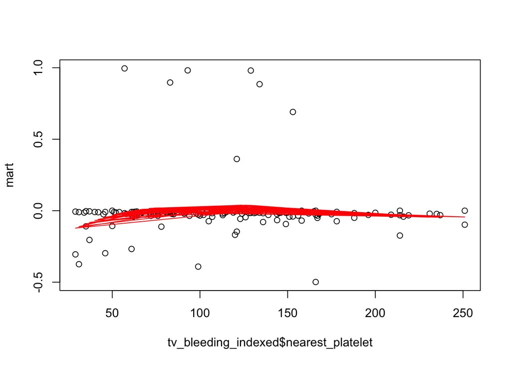

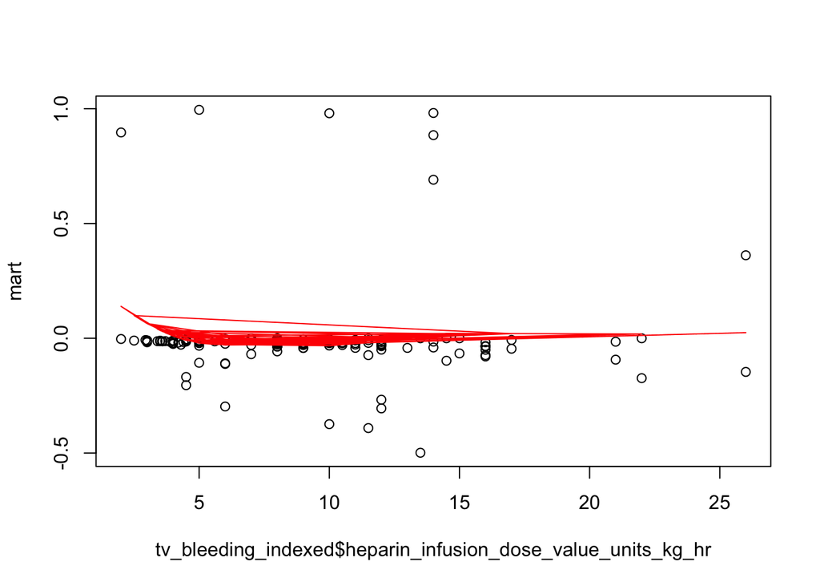

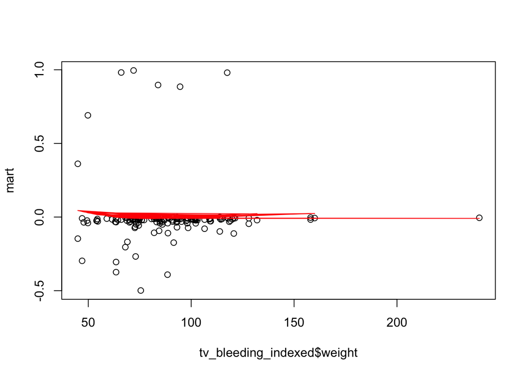

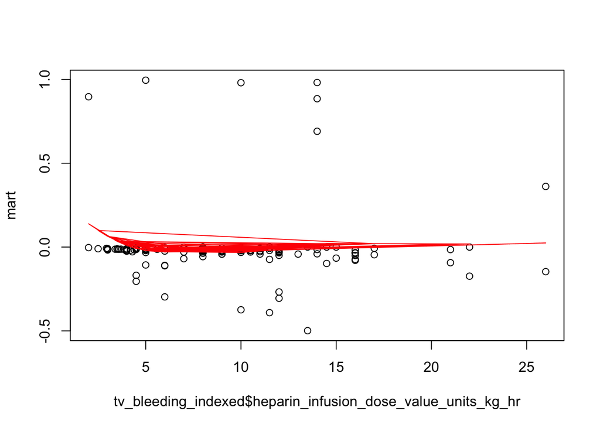

## Event per variable (EPV) / model stability

```
## [1] 5.857143
```

```
## [1] 1
```

**Limitation: we have relatively few bleeding events. Thus hazard ratios are imprecise and should be interpreted cautiously.**

# SENSITIVITY ANALYSIS EXCLUDING PATIENT WITH BOTH TYPES OF DISCORDANCE

Sensitivity: time distance (hours) between index time and covariate values used for Cox adjustment

| covariate | n_patients | median_time_h | p95_time_h | max_time_h |
| --- | --- | --- | --- | --- |
| Bilirubin | 112 | 0.43 | 10.01 | 17.15 |
| Heparin dose | 112 | 0.00 | 0.00 | 0.00 |
| INR | 109 | 0.00 | 10.13 | 23.23 |
| Platelet | 111 | 0.47 | 4.39 | 10.63 |

Sensitivity: patients with covariate time gap > 48h (nearest per covariate to index_time)

| mrn |
| --- |

Sensitivity: thrombosis TV data intervals by discordance group (with indexed labs)

| discord_group | n |
| --- | --- |
| concordant | 108 |
| aPTT > antiXa | 15 |
| aPTT < antiXa | 17 |

Sensitivity: bleeding TV data intervals by discordance group (with indexed labs)

| discord_group | n |
| --- | --- |
| concordant | 108 |
| aPTT > antiXa | 16 |
| aPTT < antiXa | 17 |

Sensitivity: time-varying Cox (thrombosis), univariable

| term | std.error | robust.se | statistic | p.value | conf.low | conf.high | HR | p_fdr | p_holm | p_bonf |
| --- | --- | --- | --- | --- | --- | --- | --- | --- | --- | --- |
| discord_groupaPTT > antiXa | 0.5434251 | 0.5184996 | -0.7553628 | 0.4500313 | 0.2446575 | 1.867471 | 0.6759371 | 0.5425006 | 0.9000626 | 0.9000626 |
| discord_groupaPTT < antiXa | 0.5413548 | 0.5590213 | -0.6090359 | 0.5425006 | 0.2378475 | 2.128032 | 0.7114401 | 0.5425006 | 0.9000626 | 1.0000000 |

Sensitivity: time-varying Cox (thrombosis) with indexed covariates; N per term (n / total)

| term | n_display | estimate | std.error | robust.se | statistic | p.value | conf.low | conf.high | n_patients | n_total | HR | p_fdr | p_holm | p_bonf |
| --- | --- | --- | --- | --- | --- | --- | --- | --- | --- | --- | --- | --- | --- | --- |
| discord_groupaPTT > antiXa | NA / NA | 0.721 | 0.570 | 0.541 | -0.604 | 0.546 | 0.250 | 2.083 | NA | NA | 0.721 | 0.764 | 1 | 1 |
| discord_groupaPTT < antiXa | NA / NA | 0.857 | 0.569 | 0.596 | -0.260 | 0.795 | 0.266 | 2.755 | NA | NA | 0.857 | 0.803 | 1 | 1 |
| nearest_inr | 108 / 108 | 2.150 | 0.633 | 0.684 | 1.119 | 0.263 | 0.563 | 8.213 | 108 | 108 | 2.150 | 0.631 | 1 | 1 |
| nearest_bilirubin | 108 / 108 | 0.815 | 0.152 | 0.178 | -1.154 | 0.248 | 0.575 | 1.154 | 108 | 108 | 0.815 | 0.631 | 1 | 1 |
| nearest_platelet | 108 / 108 | 1.001 | 0.003 | 0.003 | 0.249 | 0.803 | 0.994 | 1.008 | 108 | 108 | 1.001 | 0.803 | 1 | 1 |
| heparin_infusion_dose_value_units_kg_hr | 108 / 108 | 0.959 | 0.039 | 0.041 | -1.023 | 0.306 | 0.884 | 1.040 | 108 | 108 | 0.959 | 0.631 | 1 | 1 |
| weight | 108 / 108 | 0.995 | 0.007 | 0.006 | -0.914 | 0.361 | 0.984 | 1.006 | 108 | 108 | 0.995 | 0.631 | 1 | 1 |

Sensitivity: time-varying Cox (bleeding), univariable

| term | std.error | robust.se | statistic | p.value | conf.low | conf.high | HR | p_fdr | p_holm | p_bonf |
| --- | --- | --- | --- | --- | --- | --- | --- | --- | --- | --- |
| discord_groupaPTT > antiXa | 0.929870 | 0.7979621 | 3.376222 | 0.0007349 | 3.0960281 | 70.67372 | 14.792155 | 0.0014698 | 0.0014698 | 0.0014698 |
| discord_groupaPTT < antiXa | 1.256423 | 1.1886443 | 1.087146 | 0.2769724 | 0.3543499 | 37.40968 | 3.640895 | 0.2769724 | 0.2769724 | 0.5539448 |

Sensitivity: time-varying Cox (bleeding) with indexed covariates; N per term (n / total)

| term | n_display | estimate | std.error | robust.se | statistic | p.value | conf.low | conf.high | n_patients | n_total | HR | p_fdr | p_holm | p_bonf |
| --- | --- | --- | --- | --- | --- | --- | --- | --- | --- | --- | --- | --- | --- | --- |
| discord_groupaPTT > antiXa | NA / NA | 12.638 | 1.012 | 1.002 | 2.533 | 0.011 | 1.774 | 90.016 | NA | NA | 12.638 | 0.079 | 0.079 | 0.079 |
| discord_groupaPTT < antiXa | NA / NA | 2.574 | 1.392 | 1.293 | 0.731 | 0.465 | 0.204 | 32.448 | NA | NA | 2.574 | 0.807 | 1.000 | 1.000 |
| nearest_inr | 108 / 108 | 1.465 | 1.661 | 1.495 | 0.255 | 0.798 | 0.078 | 27.457 | 108 | 108 | 1.465 | 0.807 | 1.000 | 1.000 |
| nearest_bilirubin | 108 / 108 | 1.058 | 0.301 | 0.233 | 0.244 | 0.807 | 0.671 | 1.670 | 108 | 108 | 1.058 | 0.807 | 1.000 | 1.000 |
| nearest_platelet | 108 / 108 | 1.004 | 0.009 | 0.008 | 0.551 | 0.582 | 0.989 | 1.020 | 108 | 108 | 1.004 | 0.807 | 1.000 | 1.000 |
| heparin_infusion_dose_value_units_kg_hr | 108 / 108 | 1.074 | 0.084 | 0.066 | 1.078 | 0.281 | 0.943 | 1.224 | 108 | 108 | 1.074 | 0.807 | 1.000 | 1.000 |
| weight | 108 / 108 | 0.989 | 0.022 | 0.018 | -0.580 | 0.562 | 0.954 | 1.026 | 108 | 108 | 0.989 | 0.807 | 1.000 | 1.000 |

```
## # A tibble: 4 × 15
##   term         n_display estimate std.error robust.se statistic p.value conf.low
##   <chr>        <chr>        <dbl>     <dbl>     <dbl>     <dbl>   <dbl>    <dbl>
## 1 discord_gro… NA / NA      17.5    1.000     0.983       2.91  0.00363   2.54
## 2 discord_gro… NA / NA       3.04   1.27      1.24        0.893 0.372     0.265
## 3 nearest_inr  108 / 108     1.38   1.55      1.89        0.169 0.866     0.0340
## 4 nearest_pla… 108 / 108     1.01   0.00764   0.00756     0.854 0.393     0.992
## # ℹ 7 more variables: conf.high <dbl>, n_patients <int>, n_total <int>,
## #   HR <dbl>, p_fdr <dbl>, p_holm <dbl>, p_bonf <dbl>
```

# 4. Tertiary outcomes, i.e. those which may not be solely thrombotic or hemorrhagic, but might be associated with discordance - not reporting, consider for future exploration

- `death_date`
- `mechanical_circuit_change`
- `renal_creatinine_3_0`
- `renal_creatinine_1_5_3_0`
- `renal_renal_replacement_therapy_required`
- `metabolic_moderate_hemolysis`
- `major_hemolysis_perfusion`

Note: composited renal failure types into `renal_failure_any`

Ultimately there are very few of these outcomes (except renal failure and death).

# 5. Do counts of discordance differ when using classical (range-based) discordance categorization versus those identified with polynomial model? - CONSIDER FOR ADDITIONAL ABSTRACT

**Note that this analysis eliminated 1 lab results in which aPTT was above typical goal rangs and time-matched anti-Xa was below typical goal range and 1 lab result in which aPTT was below typical goal range and time-matched anti-Xa was above typical goal range.**

```
## # A tibble: 5 × 2
## # Groups:   concordance_classic_simple [5]
##   concordance_classic_simple       n
##   <fct>                        <int>
## 1 concordant                     379
## 2 discordant aPTT below antiXa   148
## 3 discordant aPTT above antiXa    42
## 4 high aPTT low antiXa             1
## 5 low aPTT high antiXa             1
```

```
## # A tibble: 5 × 2
## # Groups:   concordance_low_simple [5]
##   concordance_low_simple           n
##   <fct>                        <int>
## 1 concordant                     327
## 2 discordant aPTT below antiXa   183
## 3 discordant aPTT above antiXa    59
## 4 high aPTT low antiXa             1
## 5 low aPTT high antiXa             1
```

```
##
## Counts (Classic):
```

```
## # A tibble: 2 × 2
##   classic_discordant     n
##   <lgl>              <int>
## 1 FALSE                 49
## 2 TRUE                  63
```

```
##
## Counts (Modeled):
```

```
## # A tibble: 2 × 2
##   modeled_discordant     n
##   <lgl>              <int>
## 1 FALSE                 77
## 2 TRUE                  35
```

```
##
## Classic vs Modeled Discordance Table:
```

```
##        modeled
## classic FALSE TRUE
##   FALSE    43    6
##   TRUE     34   29
```

```
## # A tibble: 4 × 3
##   classic modeled     n
##   <chr>   <chr>   <int>
## 1 FALSE   FALSE      43
## 2 TRUE    FALSE      34
## 3 FALSE   TRUE        6
## 4 TRUE    TRUE       29
```

```
##
## McNemar Test:
```

```
##
##  McNemar's Chi-squared test with continuity correction
##
## data:  discord_table
## McNemar's chi-squared = 18.225, df = 1, p-value = 1.963e-05
```

```
## # A tibble: 1 × 4
##   statistic   p.value parameter method
##       <dbl>     <dbl>     <dbl> <chr>
## 1      18.2 0.0000196         1 McNemar's Chi-squared test with continuity corr…
```

```
## === 3×3 Classification Table (Classic vs Polynomial Model) ===
```

```
##                modeled
## classic         aPTT < antiXa aPTT > antiXa concordant
##   aPTT < antiXa            14             4         30
##   aPTT > antiXa             0            11          4
##   concordant                4             2         43
```

```
##
## === Chi-square Test ===
```

```
##
##  Pearson's Chi-squared test with simulated p-value (based on 5000
##  replicates)
##
## data:  discord_table_full
## X-squared = 55.029, df = NA, p-value = 2e-04
```

```
##
## === Discordant-Only 2×2 Table (Low vs High) ===
```

```
##                modeled
## classic         aPTT < antiXa aPTT > antiXa concordant
##   aPTT < antiXa            14             4         30
##   aPTT > antiXa             0            11          4
##   concordant                4             2          0
```

```
## # A tibble: 9 × 3
##   classic       modeled           n
##   <chr>         <chr>         <int>
## 1 aPTT < antiXa aPTT < antiXa    14
## 2 aPTT > antiXa aPTT < antiXa     0
## 3 concordant    aPTT < antiXa     4
## 4 aPTT < antiXa aPTT > antiXa     4
## 5 aPTT > antiXa aPTT > antiXa    11
## 6 concordant    aPTT > antiXa     2
## 7 aPTT < antiXa concordant       30
## 8 aPTT > antiXa concordant        4
## 9 concordant    concordant        0
```

```
##
## === Chi-square Test (Discordant Types Only) ===
```

```
##
##  Pearson's Chi-squared test with simulated p-value (based on 5000
##  replicates)
##
## data:  discord_types
## X-squared = 33.891, df = NA, p-value = 2e-04
```

```
## # A tibble: 1 × 4
##   statistic  p.value parameter method
##       <dbl>    <dbl> <lgl>     <chr>
## 1      33.9 0.000200 NA        "Pearson's Chi-squared test with simulated p-val…
```

# 6. Do counts of complications by discordance type differ when using classical (range-based) discordance categorization versus those identified with polynomial model?

**Note that this analysis eliminated 1 lab results in which aPTT was above typical goal range and time-matched anti-Xa was below typical goal range and 1 lab result in which aPTT was below typical goal range and time-matched anti-Xa was above typical goal range.**

```
##
## =============================
## Category: aPTT < antiXa
## =============================
## # A tibble: 1 × 3
##       n thromb_n thromb_rate
##   <int>    <int>       <dbl>
## 1    48       20       0.417
## # A tibble: 1 × 3
##       n thromb_n thromb_rate
##   <int>    <int>       <dbl>
## 1    18        4       0.222
##
## 2×2 Thrombosis Table:
##         thrombosis no_thrombosis
## classic         20            28
## modeled          4            14
##
## Fisher Test:
##
##  Fisher's Exact Test for Count Data
##
## data:  table_mat
## p-value = 0.1649
## alternative hypothesis: true odds ratio is not equal to 1
## 95 percent confidence interval:
##   0.6438088 11.8457795
## sample estimates:
## odds ratio
##   2.467387
##
##
##
##
## =============================
## Category: aPTT > antiXa
## =============================
## # A tibble: 1 × 3
##       n thromb_n thromb_rate
##   <int>    <int>       <dbl>
```

[output cut: 41 more lines]

```
## classic         18            31
## modeled         34            43
##
## Fisher Test:
##
##  Fisher's Exact Test for Count Data
##
## data:  table_mat
## p-value = 0.4607
## alternative hypothesis: true odds ratio is not equal to 1
## 95 percent confidence interval:
##  0.3280859 1.6249909
## sample estimates:
## odds ratio
##  0.7361483
```

```
##
## =============================
## Category: aPTT < antiXa
## =============================
## # A tibble: 1 × 3
##       n hemorrhage_n hemorrhage_rate
##   <int>        <int>           <dbl>
## 1    48            2          0.0417
## # A tibble: 1 × 3
##       n hemorrhage_n hemorrhage_rate
##   <int>        <int>           <dbl>
## 1    18            1          0.0556
##
## 2×2 Hemorrhage Table:
##         hemorrhage no_hemorrhage
## classic          2            46
## modeled          1            17
##
## Fisher Test:
##
##  Fisher's Exact Test for Count Data
##
## data:  table_mat
## p-value = 1
## alternative hypothesis: true odds ratio is not equal to 1
## 95 percent confidence interval:
##   0.03641973 46.14255757
## sample estimates:
## odds ratio
##    0.74273
##
##
##
##
## =============================
## Category: aPTT > antiXa
## =============================
## # A tibble: 1 × 3
##       n hemorrhage_n hemorrhage_rate
##   <int>        <int>           <dbl>
```

[output cut: 41 more lines]

```
## classic          3            46
## modeled          3            74
##
## Fisher Test:
##
##  Fisher's Exact Test for Count Data
##
## data:  table_mat
## p-value = 0.6769
## alternative hypothesis: true odds ratio is not equal to 1
## 95 percent confidence interval:
##   0.2058079 12.4748253
## sample estimates:
## odds ratio
##   1.602364
```

```
##
## =============================
## Low Range vs Polynomial — Thrombosis
## Category: aPTT < antiXa
## =============================
## # A tibble: 1 × 3
##       n thromb_n thromb_rate
##   <int>    <int>       <dbl>
## 1    65       24       0.369
## # A tibble: 1 × 3
##       n thromb_n thromb_rate
##   <int>    <int>       <dbl>
## 1    18        4       0.222
##
## 2×2 Table:
##           thrombosis no_thrombosis
## low_range         24            41
## modeled            4            14
##
## Fisher Test:
##
##  Fisher's Exact Test for Count Data
##
## data:  table_mat
## p-value = 0.2766
## alternative hypothesis: true odds ratio is not equal to 1
## 95 percent confidence interval:
##  0.5519251 9.4577870
## sample estimates:
## odds ratio
##   2.032359
##
##
##
##
## =============================
## Low Range vs Polynomial — Thrombosis
## Category: aPTT > antiXa
## =============================
## # A tibble: 1 × 3
```

[output cut: 44 more lines]

```
## low_range         12            16
## modeled           34            43
##
## Fisher Test:
##
##  Fisher's Exact Test for Count Data
##
## data:  table_mat
## p-value = 1
## alternative hypothesis: true odds ratio is not equal to 1
## 95 percent confidence interval:
##  0.3573489 2.4714823
## sample estimates:
## odds ratio
##  0.9489871
```

# LAB based unadjusted analysis => NOT TO REPORT

```
## # A tibble: 3 × 4
##   unusual_type      n hemorrhage_rate thrombosis_rate
##   <fct>         <int>           <dbl>           <dbl>
## 1 concordant      477            7.13            29.8
## 2 aPTT > antiXa    36           11.1             25
## 3 aPTT < antiXa    58            1.72            24.1
```

```
##
## Call:  glm(formula = hemorrhage_any ~ unusual_type, family = binomial,
##     data = model_fit_complications)
##
## Coefficients:
##               (Intercept)  unusual_typeaPTT > antiXa
##                   -2.5672                     0.4878
## unusual_typeaPTT < antiXa
##                   -1.4758
##
## Degrees of Freedom: 570 Total (i.e. Null);  568 Residual
## Null Deviance:       284.6
## Residual Deviance: 280.3     AIC: 286.3
```

```
##
## Call:
## glm(formula = hemorrhage_any ~ unusual_type, family = binomial,
##     data = model_fit_complications)
##
## Coefficients:
##                           Estimate Std. Error z value Pr(>|z|)
## (Intercept)                -2.5672     0.1780 -14.426   <2e-16 ***
## unusual_typeaPTT > antiXa   0.4878     0.5594   0.872    0.383
## unusual_typeaPTT < antiXa  -1.4758     1.0241  -1.441    0.150
## ---
## Signif. codes:  0 '***' 0.001 '**' 0.01 '*' 0.05 '.' 0.1 ' ' 1
##
## (Dispersion parameter for binomial family taken to be 1)
##
##     Null deviance: 284.61  on 570  degrees of freedom
## Residual deviance: 280.33  on 568  degrees of freedom
## AIC: 286.33
##
## Number of Fisher Scoring iterations: 6
```

```
##
## Call:  glm(formula = thrombosis_any ~ unusual_type, family = binomial,
##     data = model_fit_complications)
##
## Coefficients:
##               (Intercept)  unusual_typeaPTT > antiXa
##                   -0.8583                    -0.2403
## unusual_typeaPTT < antiXa
##                   -0.2868
##
## Degrees of Freedom: 570 Total (i.e. Null);  568 Residual
## Null Deviance:       686.6
## Residual Deviance: 685.5     AIC: 691.5
```

```
##
## Call:
## glm(formula = thrombosis_any ~ unusual_type, family = binomial,
##     data = model_fit_complications)
##
## Coefficients:
##                           Estimate Std. Error z value Pr(>|z|)
## (Intercept)                -0.8583     0.1001  -8.571   <2e-16 ***
## unusual_typeaPTT > antiXa  -0.2403     0.3977  -0.604    0.546
## unusual_typeaPTT < antiXa  -0.2868     0.3228  -0.889    0.374
## ---
## Signif. codes:  0 '***' 0.001 '**' 0.01 '*' 0.05 '.' 0.1 ' ' 1
##
## (Dispersion parameter for binomial family taken to be 1)
##
##     Null deviance: 686.60  on 570  degrees of freedom
## Residual deviance: 685.49  on 568  degrees of freedom
## AIC: 691.49
##
## Number of Fisher Scoring iterations: 4
```

# LAB based adjusted analysis - note that this NOT PATIENT LEVEL => NOT TO REPORT

```
##
## Call:
## glm(formula = hemorrhage_any ~ unusual_type + duration_to_lab +
##     international_normalization_ratio + fibrinogen + nearest_bilirubin +
##     weight + heparin_infusion_dose_value_units_kg_hr, family = binomial,
##     data = model_fit_complications)
##
## Coefficients:
##                                           Estimate Std. Error z value Pr(>|z|)
## (Intercept)                              5.437e-01  3.189e+00   0.170  0.86462
## unusual_typeaPTT > antiXa               -1.629e+01  1.751e+03  -0.009  0.99258
## unusual_typeaPTT < antiXa               -4.178e-01  1.301e+00  -0.321  0.74816
## duration_to_lab                         -1.206e-03  4.098e-03  -0.294  0.76857
## international_normalization_ratio        1.358e+00  2.296e+00   0.592  0.55404
## fibrinogen                               2.194e-05  1.954e-03   0.011  0.99104
## nearest_bilirubin                       -4.498e-01  4.408e-01  -1.020  0.30753
## weight                                  -6.816e-02  2.174e-02  -3.135  0.00172
## heparin_infusion_dose_value_units_kg_hr  1.732e-01  9.296e-02   1.863  0.06248
##
## (Intercept)
## unusual_typeaPTT > antiXa
## unusual_typeaPTT < antiXa
## duration_to_lab
## international_normalization_ratio
## fibrinogen
## nearest_bilirubin
## weight                                  **
## heparin_infusion_dose_value_units_kg_hr .
## ---
## Signif. codes:  0 '***' 0.001 '**' 0.01 '*' 0.05 '.' 0.1 ' ' 1
##
## (Dispersion parameter for binomial family taken to be 1)
##
##     Null deviance: 86.459  on 167  degrees of freedom
## Residual deviance: 61.610  on 159  degrees of freedom
##   (403 observations deleted due to missingness)
## AIC: 79.61
##
## Number of Fisher Scoring iterations: 16
```

VIF collinearity check for hemorrhage multivariable model

|  | GVIF | Df | GVIF^(1/(2*Df)) |
| --- | --- | --- | --- |
| unusual_type | 1.355896 | 2 | 1.079087 |
| duration_to_lab | 1.755864 | 1 | 1.325090 |
| international_normalization_ratio | 1.304064 | 1 | 1.141956 |
| fibrinogen | 1.407007 | 1 | 1.186173 |
| nearest_bilirubin | 1.147931 | 1 | 1.071416 |
| weight | 1.595967 | 1 | 1.263316 |
| heparin_infusion_dose_value_units_kg_hr | 1.836584 | 1 | 1.355206 |

```
## # A tibble: 9 × 8
##   term                        OR conf.low conf.high   p_raw  p_fdr p_holm p_bonf
##   <chr>                    <dbl>    <dbl>     <dbl>   <dbl>  <dbl>  <dbl>  <dbl>
## 1 (Intercept)            1.72e+0  0.00588  2.22e+ 3 0.865   0.993  1      1
## 2 unusual_typeaPTT > an… 8.44e-8 NA        7.69e+56 0.993   0.993  1      1
## 3 unusual_typeaPTT < an… 6.59e-1  0.0276   7.14e+ 0 0.748   0.993  1      1
## 4 duration_to_lab        9.99e-1  0.990    1.01e+ 0 0.769   0.993  1      1
## 5 international_normali… 3.89e+0  0.0134   1.70e+ 2 0.554   0.993  1      1
## 6 fibrinogen             1.00e+0  0.996    1.00e+ 0 0.991   0.993  1      1
## 7 nearest_bilirubin      6.38e-1  0.209    1.21e+ 0 0.308   0.923  1      1
## 8 weight                 9.34e-1  0.890    9.71e- 1 0.00172 0.0155 0.0155 0.0155
## 9 heparin_infusion_dose… 1.19e+0  1.00     1.45e+ 0 0.0625  0.281  0.500  0.562
```

```
## [1] TRUE
```

```
##
##                 FALSE TRUE
##   concordant      443   34
##   aPTT > antiXa    32    4
##   aPTT < antiXa    57    1
```

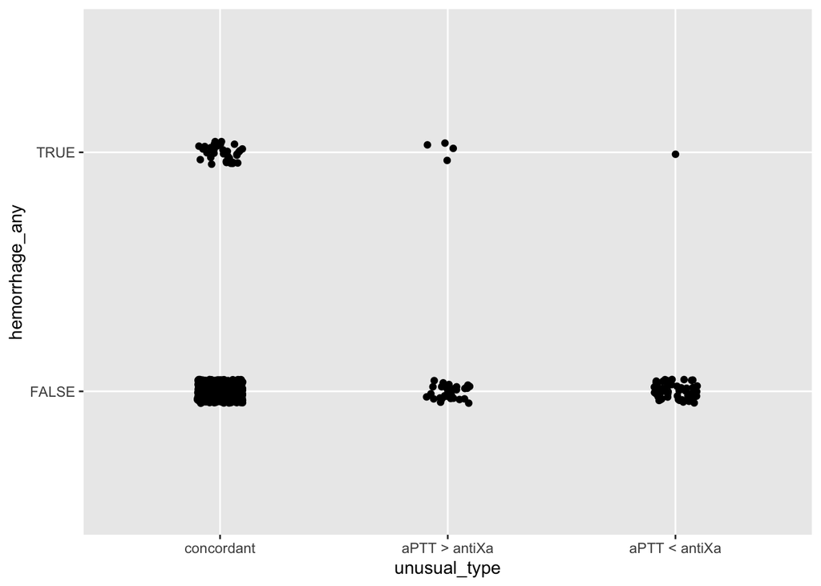

Hemorrhage Firth Penalized Regression Results

| term | estimate | OR | conf.low | conf.high | p_raw | p_fdr | p_holm | p_bonf |
| --- | --- | --- | --- | --- | --- | --- | --- | --- |
| (Intercept) | -0.4517335 | 0.6365238 | 0.0055107 | 394.8943525 | 0.8573556 | 0.9645251 | 1.0000000 | 1.0000000 |
| unusual_typeaPTT > antiXa | -1.1943994 | 0.3028858 | 0.0019908 | 4.7298196 | 0.4328422 | 0.8319527 | 1.0000000 | 1.0000000 |
| unusual_typeaPTT < antiXa | -0.2020069 | 0.8170893 | 0.0680678 | 6.1958257 | 0.8512867 | 0.9645251 | 1.0000000 | 1.0000000 |
| duration_to_lab | -0.0008927 | 0.9991077 | 0.9914045 | 1.0066575 | 0.8082157 | 0.9645251 | 1.0000000 | 1.0000000 |
| international_normalization_ratio | 1.7131475 | 5.5463913 | 0.0361873 | 90.6128738 | 0.3617986 | 0.8319527 | 1.0000000 | 1.0000000 |
| fibrinogen | -0.0000540 | 0.9999460 | 0.9962827 | 1.0036019 | 0.9762417 | 0.9762417 | 1.0000000 | 1.0000000 |
| nearest_bilirubin | -0.2232760 | 0.7998941 | 0.3003558 | 1.2897960 | 0.4621959 | 0.8319527 | 1.0000000 | 1.0000000 |
| weight | -0.0575024 | 0.9441196 | 0.9050462 | 0.9775113 | 0.0009199 | 0.0082792 | 0.0082792 | 0.0082792 |
| heparin_infusion_dose_value_units_kg_hr | 0.1432434 | 1.1540107 | 0.9887063 | 1.3823250 | 0.0701087 | 0.3154892 | 0.5608697 | 0.6309784 |

```
##
## Call:
## glm(formula = thrombosis_any ~ unusual_type + international_normalization_ratio +
##     heparin_infusion_dose_value_units_kg_hr + duration_to_lab +
##     fibrinogen + nearest_bilirubin + weight, family = binomial,
##     data = model_fit_complications)
##
## Coefficients:
##                                           Estimate Std. Error z value Pr(>|z|)
## (Intercept)                              4.201e-01  1.858e+00   0.226 0.821126
## unusual_typeaPTT > antiXa               -1.488e+01  1.056e+03  -0.014 0.988756
## unusual_typeaPTT < antiXa                1.348e+00  5.398e-01   2.497 0.012509
## international_normalization_ratio       -5.654e-01  1.228e+00  -0.460 0.645206
## heparin_infusion_dose_value_units_kg_hr -2.186e-01  6.284e-02  -3.478 0.000505
## duration_to_lab                         -7.959e-03  3.629e-03  -2.193 0.028276
## fibrinogen                              -8.438e-04  9.307e-04  -0.907 0.364581
## nearest_bilirubin                        2.562e-02  1.347e-01   0.190 0.849085
## weight                                   2.474e-02  1.010e-02   2.449 0.014327
##
## (Intercept)
## unusual_typeaPTT > antiXa
## unusual_typeaPTT < antiXa               *
## international_normalization_ratio
## heparin_infusion_dose_value_units_kg_hr ***
## duration_to_lab                         *
## fibrinogen
## nearest_bilirubin
## weight                                  *
## ---
## Signif. codes:  0 '***' 0.001 '**' 0.01 '*' 0.05 '.' 0.1 ' ' 1
##
## (Dispersion parameter for binomial family taken to be 1)
##
##     Null deviance: 202.82  on 167  degrees of freedom
## Residual deviance: 162.36  on 159  degrees of freedom
##   (403 observations deleted due to missingness)
## AIC: 180.36
##
## Number of Fisher Scoring iterations: 15
```

```
## # A tibble: 9 × 7
##   term                   estimate std.error statistic p.value conf.low conf.high
##   <chr>                     <dbl>     <dbl>     <dbl>   <dbl>    <dbl>     <dbl>
## 1 (Intercept)             1.52e+0   1.86e+0    0.226  8.21e-1   0.0413  7.45e+ 1
## 2 unusual_typeaPTT > an…  3.44e-7   1.06e+3   -0.0141 9.89e-1  NA       3.54e+40
## 3 unusual_typeaPTT < an…  3.85e+0   5.40e-1    2.50   1.25e-2   1.37    1.16e+ 1
## 4 international_normali…  5.68e-1   1.23e+0   -0.460  6.45e-1   0.0384  6.00e+ 0
## 5 heparin_infusion_dose…  8.04e-1   6.28e-2   -3.48   5.05e-4   0.705   9.03e- 1
## 6 duration_to_lab         9.92e-1   3.63e-3   -2.19   2.83e-2   0.985   9.99e- 1
## 7 fibrinogen              9.99e-1   9.31e-4   -0.907  3.65e-1   0.997   1.00e+ 0
## 8 nearest_bilirubin       1.03e+0   1.35e-1    0.190  8.49e-1   0.769   1.32e+ 0
## 9 weight                  1.03e+0   1.01e-2    2.45   1.43e-2   1.01    1.05e+ 0
```

VIF collinearity check for thrombosis multivariable model

|  | GVIF | Df | GVIF^(1/(2*Df)) |
| --- | --- | --- | --- |
| unusual_type | 1.258849 | 2 | 1.059238 |
| international_normalization_ratio | 1.408611 | 1 | 1.186849 |
| heparin_infusion_dose_value_units_kg_hr | 1.503484 | 1 | 1.226166 |
| duration_to_lab | 1.323139 | 1 | 1.150278 |
| fibrinogen | 1.322245 | 1 | 1.149889 |
| nearest_bilirubin | 1.418127 | 1 | 1.190851 |
| weight | 1.346531 | 1 | 1.160401 |

```
## # A tibble: 9 × 8
##   term                     OR conf.low conf.high   p_raw   p_fdr  p_holm  p_bonf
##   <chr>                 <dbl>    <dbl>     <dbl>   <dbl>   <dbl>   <dbl>   <dbl>
## 1 (Intercept)         1.52e+0   0.0413  7.45e+ 1 8.21e-1 0.955   1       1
## 2 unusual_typeaPTT >… 3.44e-7  NA       3.54e+40 9.89e-1 0.989   1       1
## 3 unusual_typeaPTT <… 3.85e+0   1.37    1.16e+ 1 1.25e-2 0.0430  0.100   0.113
## 4 international_norm… 5.68e-1   0.0384  6.00e+ 0 6.45e-1 0.955   1       1
## 5 heparin_infusion_d… 8.04e-1   0.705   9.03e- 1 5.05e-4 0.00454 0.00454 0.00454
## 6 duration_to_lab     9.92e-1   0.985   9.99e- 1 2.83e-2 0.0636  0.170   0.254
## 7 fibrinogen          9.99e-1   0.997   1.00e+ 0 3.65e-1 0.656   1       1
## 8 nearest_bilirubin   1.03e+0   0.769   1.32e+ 0 8.49e-1 0.955   1       1
## 9 weight              1.03e+0   1.01    1.05e+ 0 1.43e-2 0.0430  0.100   0.129
```

```
## [1] TRUE
```

```
##
##                 FALSE TRUE
##   concordant      335  142
##   aPTT > antiXa    27    9
##   aPTT < antiXa    44   14
```

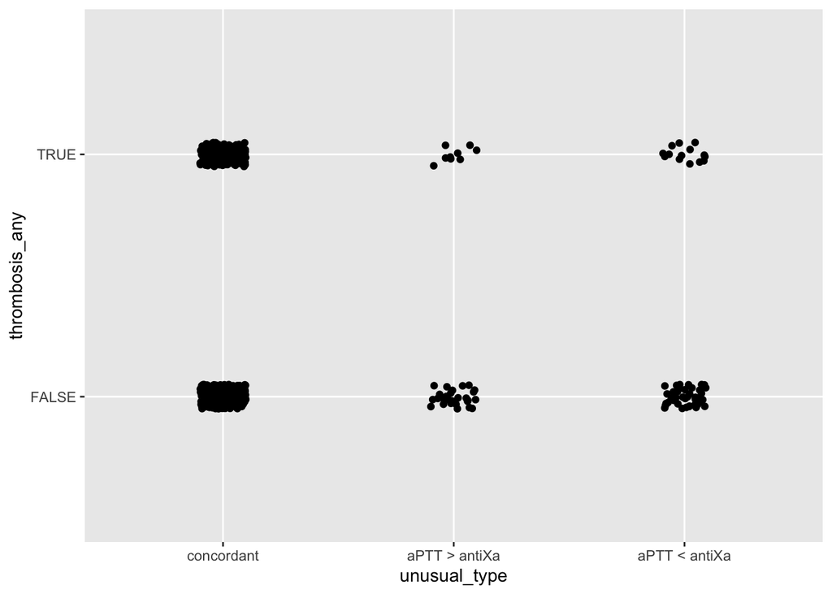

Thrombosis Firth Penalized Regression Results

| term | estimate | OR | conf.low | conf.high | p_raw | p_fdr | p_holm | p_bonf |
| --- | --- | --- | --- | --- | --- | --- | --- | --- |
| (Intercept) | 0.3112238 | 1.3650946 | 0.0489856 | 50.5729181 | 0.8542002 | 0.8542002 | 1.0000000 | 1.0000000 |
| unusual_typeaPTT > antiXa | -0.8812509 | 0.4142644 | 0.0029282 | 5.0395611 | 0.5416406 | 0.8124609 | 1.0000000 | 1.0000000 |
| unusual_typeaPTT < antiXa | 1.2449190 | 3.4726536 | 1.2893237 | 9.9483446 | 0.0136282 | 0.0408845 | 0.0953973 | 0.1226536 |
| duration_to_lab | -0.0073757 | 0.9926514 | 0.9854777 | 0.9991030 | 0.0247555 | 0.0556998 | 0.1485328 | 0.2227992 |
| international_normalization_ratio | -0.4233769 | 0.6548318 | 0.0549153 | 5.3981260 | 0.6915597 | 0.8542002 | 1.0000000 | 1.0000000 |
| fibrinogen | -0.0008607 | 0.9991397 | 0.9973761 | 1.0009172 | 0.3391874 | 0.6105373 | 1.0000000 | 1.0000000 |
| nearest_bilirubin | 0.0386472 | 1.0394037 | 0.7886354 | 1.3062943 | 0.7627375 | 0.8542002 | 1.0000000 | 1.0000000 |
| weight | 0.0223096 | 1.0225603 | 1.0054031 | 1.0444797 | 0.0081549 | 0.0366972 | 0.0652394 | 0.0733944 |
| heparin_infusion_dose_value_units_kg_hr | -0.1996967 | 0.8189791 | 0.7221164 | 0.9152349 | 0.0002459 | 0.0022128 | 0.0022128 | 0.0022128 |

### LAB based, not patient-level, Sensitivity Analysis in which Discordance is Grouped - not to report

```r
hemorrhage_simple = glm(hemorrhage_any ~ discordance_any + duration_to_lab + nearest_bilirubin + fibrinogen + international_normalization_ratio + weight + heparin_infusion_dose_value_units_kg_hr, data = model_fit_complications, family = binomial)

hemorrhage_simple %>% broom::tidy(exponentiate = TRUE, conf.int = TRUE)
```

```
## # A tibble: 8 × 7
##   term                   estimate std.error statistic p.value conf.low conf.high
##   <chr>                     <dbl>     <dbl>     <dbl>   <dbl>    <dbl>     <dbl>
## 1 (Intercept)               1.44    3.15        0.116 0.908    0.00507  1826.
## 2 discordance_anydiscor…    0.351   1.25       -0.836 0.403    0.0154      3.27
## 3 duration_to_lab           1.000   0.00402    -0.102 0.919    0.991       1.01
## 4 nearest_bilirubin         0.635   0.451      -1.01  0.314    0.204       1.21
## 5 fibrinogen                1.000   0.00191    -0.152 0.879    0.996       1.00
## 6 international_normali…    4.12    2.25        0.629 0.529    0.0138    173.
## 7 weight                    0.938   0.0209     -3.07  0.00218  0.896       0.974
## 8 heparin_infusion_dose…    1.17    0.0900      1.74  0.0818   0.989       1.41
```

```r
thrombosis_simple = glm(thrombosis_any ~ discordance_any + duration_to_lab + international_normalization_ratio + weight + heparin_infusion_dose_value_units_kg_hr + nearest_bilirubin + fibrinogen, data = model_fit_complications, family = binomial)

thrombosis_simple %>% broom::tidy(exponentiate = TRUE, conf.int = TRUE)
```

```
## # A tibble: 8 × 7
##   term                   estimate std.error statistic p.value conf.low conf.high
##   <chr>                     <dbl>     <dbl>     <dbl>   <dbl>    <dbl>     <dbl>
## 1 (Intercept)               0.994  1.86      -0.00297 9.98e-1   0.0268    48.6
## 2 discordance_anydiscor…    2.96   0.513      2.12    3.42e-2   1.10       8.34
## 3 duration_to_lab           0.993  0.00349   -1.90    5.77e-2   0.986      1.000
## 4 international_normali…    0.591  1.23      -0.428   6.69e-1   0.0397     6.26
## 5 weight                    1.03   0.0103     2.87    4.17e-3   1.01       1.05
## 6 heparin_infusion_dose…    0.787  0.0629    -3.82    1.36e-4   0.690      0.884
## 7 nearest_bilirubin         1.05   0.133      0.367   7.13e-1   0.791      1.34
## 8 fibrinogen                0.999  0.000927  -1.04    2.98e-1   0.997      1.00
```

### Lab-based, not patient level, Sensitivity Analysis in which outcomes are grouped

```r
complication_simple = glm(coag_event_any ~ unusual_type + duration_to_lab + nearest_bilirubin + fibrinogen + international_normalization_ratio + weight + heparin_infusion_dose_value_units_kg_hr, data = model_fit_complications, family = binomial)

complication_simple %>% broom::tidy()
```

```
## # A tibble: 8 × 5
##   term                                     estimate std.error statistic p.value
##   <chr>                                       <dbl>     <dbl>     <dbl>   <dbl>
## 1 (Intercept)                             -2.66e+ 1   545666. -4.87e- 5   1.000
## 2 unusual_typeaPTT < antiXa               -1.77e-14   124884. -1.42e-19   1
## 3 duration_to_lab                         -2.71e-19      625. -4.34e-22   1
## 4 nearest_bilirubin                        2.35e-15    50094.  4.69e-20   1
## 5 fibrinogen                               1.50e-17      298.  5.04e-20   1
## 6 international_normalization_ratio       -3.91e-14   349714. -1.12e-19   1
## 7 weight                                  -2.27e-16     2719. -8.35e-20   1
## 8 heparin_infusion_dose_value_units_kg_hr -9.92e-16    11855. -8.37e-20   1
```

Standard logistic regression had high separation based on discordance type, likely due to uncommon outcome among a relatively small sample size with several critical covariables. Thus, Firth penalized logistic regression used to compute odds ratios and p-values.

# FIGURES FOR PUBLICATION

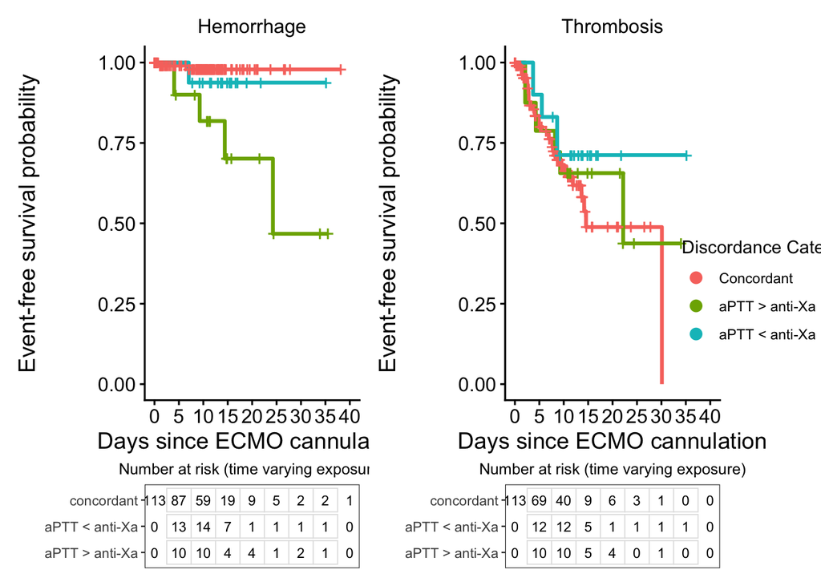

# CONCLUSIONS

- thrombotic and hemorrhagic events are common among ECMO patients
- thrombotic events occurred frequently, despite heparin use in this sample (initiation of ECMO induces a hypercoagulable state which is associated with thrombosis development)
- there is moderate correlation between aPTT and antiXa among heparinized ECMO patients
- categorizing discordance based on aPTT range:anti-Xa range may not effectively recognize values which are relatively unusual (to each other) at CUIMC. The counts of patients who are discordant based on classic groupings based on usual CUIMC systemic anticoagulation goals are different (numerically higher) than those with relative comparison via polynomial model used in this approach. Our approach may better recognize truly unusual values.
- the relative aPTT:antiXa value is more important than absolute values. Classifying discordance by range alone (i.e. within wide goal ranges) may not appropriately recognize hyper- or hypocoagulable states.